# Time Series Analysis

# 1. Prologue

```r
library(FitAR)
library(forecast)
library(tseries)
library(gplots)
library(aTSA)
library(astsa)
```

```r
food.df <- read.csv("time_series.csv")
```

# 2. Time Series Introduction

## 2.1. What is Time Series?

A time series is a series of data points indexed (or listed or graphed) in time order. Most commonly, a time series is a sequence taken at successive equally spaced points in time. Thus it is a sequence of discrete-time data. Examples of time series are heights of ocean tides, counts of sunspots, and the daily closing value of the Dow Jones Industrial Average.

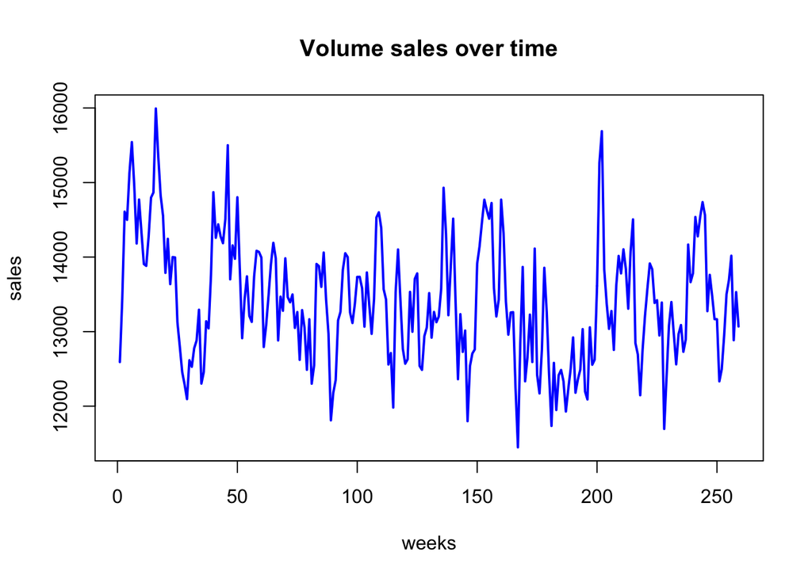

```r
plot(food.df[,c(1)],food.df[,c(2)], type="l", col="blue", lwd=2, xlab="weeks", ylab="sales", main="Volume sales over time")
```

## 2.2. The Concept of White Noise

White noise is a type of time series with some particular characteristics: By definition, white noise is not predictable. Whenever we do a time series analysis, we assume that our outcome variable $y_t$ is a comination of signal (something predictable) $+$ noise (something random). If you can prove that your residuals are, in fact, white noise… It means that your model fully captured the noise and you did a good job! Hence, if you can prove that your residuals are white noise, you can prove the validity of your model. \ How do we test for white noise?

## 2.3. Autocovariance of a Stochastic (Random) Process

### 2.3.1. Covariance

Covariance is a measure of joint variability of two random variables. If greater values of one variable mainly correspond with greater values of the other variable - and the same holds for lesser values = the covariance is positive. If greater values of one variable correspond with lesser values of the other, covariance is negative.
$$cov_{x,y}=\frac{\sum_{i=1}^{N}(x_{i}-\bar{x})(y_{i}-\bar{y})}{N-1}$$

### 2.3.2. AutoCovariance

Autocovariance is a function that gives the covariance of the process with itself at pairs of time points.

$$K_{XX}(t_1, t_2) = cov[X_1, X_2]$$
$$cov[X_1, X_2] = E[(X_{t_1} - \mu_{t_1}) (X_{t_2} - \mu_{t_2})]$$
$$E[(X_{t_1} - \mu_{t_1}) (X_{t_2} - \mu_{t_2})] = E[X_{t_1} X_{t_2}] - \mu_{t_1}\mu_{t_2}$$

## 2.4. The Gaus-Markov Theorem & Time Series Analysis

The Gauss-Markov theorem states that if your lienar regression model satisfies the first six classical assumptions, the ordinary least squares regression produces unbiased estimates that have the smalles variance of all possible estimators. In simpler terms, if you make sure to satisfy the 6 classical Gauss-Markov assumptions, you ordinary least square coefficients will be the best they can be!

It should be noted that these assumptions differ for time series data (versus cross-sectional data).